# Code Assignment 1

Team 5

Due: 2021-09-29 23:59

# Case Study

A Florida health insurance company wants to predict annual claims for individual clients. The company pulls a random sample of 50 customers. The owner wishes to charge an actuarially fair premium to ensure a normal rate of return. The owner collects all of their current customer’s health care expenses from the last year and compares them with what is known about each customer’s plan.

The data on the 50 customers in the sample is as follows:

- Charges: Total medical expenses for a particular insurance plan (in dollars)
- Age: Age of the primary beneficiary
- BMI: Primary beneficiary’s body mass index (kg/m2)
- Female: Primary beneficiary’s birth sex (0 = Male, 1 = Female)
- Children: Number of children covered by health insurance plan (includes other dependents as well)
- Smoker: Indicator if primary beneficiary is a smoker (0 = non-smoker, 1 = smoker)
- Cities: Dummy variables for each city with the default being Sanford

Answer the following questions using complete sentences and attach all output, plots, etc. within this report.

*For this assignment, ignore the categorical variables (gender, smoker, cities)*

## Question 1

Perform univariate analyses on the quantitative variables (center, shape, spread). Include descriptive statistics, and histograms. Be sure to use terms discussed in class such as bimodal, skewed left, etc.

### Inspect, and Clean the Data

First, we should inspect the data to determine if all variables within the data set to ensure they make sense. The below output of observations and variables indicate that there are categorical and Quantitative variables.

```
## tibble [50 × 9] (S3: tbl_df/tbl/data.frame)
##  $ Charges      : num [1:50] 9145 7441 12143 3260 19023 ...
##  $ Age          : num [1:50] 52 45 60 31 39 25 25 57 34 42 ...
##  $ BMI          : num [1:50] 36.7 30.2 25.7 20.4 18.3 ...
##  $ Female       : num [1:50] 0 0 0 0 1 1 1 1 0 0 ...
##  $ Children     : num [1:50] 0 1 0 0 5 1 0 2 1 2 ...
##  $ Smoker       : num [1:50] 0 0 0 0 1 0 1 0 1 0 ...
##  $ WinterSprings: num [1:50] 0 0 0 0 0 0 0 0 0 0 ...
##  $ WinterPark   : num [1:50] 0 0 1 0 0 1 0 0 0 1 ...
##  $ Oviedo       : num [1:50] 1 1 0 1 1 0 1 1 0 0 ...
```

Below is the below code chunk will be removing the categorical data from summaries for our analysis.

```r
Insurance$Female <- NULL
Insurance$WinterPark <- NULL
Insurance$WinterSprings <- NULL
Insurance$Oviedo <- NULL
Insurance$Smoker <- NULL
```

### Center (Mean, Median)

| **Characteristic** | **N = 50**<sup>1</sup> |
| --- | --- |
| Charges |  |
| Mean (SD) | 12,142 (11,317) |
| Median (IQR) | 8,333 (4,360, 13,720) |
| Range | 2,494, 55,135 |
| Age |  |
| Mean (SD) | 42 (13) |
| Median (IQR) | 40 (30, 53) |
| Range | 23, 64 |
| BMI |  |
| Mean (SD) | 28.7 (5.6) |
| Median (IQR) | 28.0 (25.2, 32.2) |
| Range | 16.8, 42.1 |
| Children |  |
| 0 | 17 / 50 (34%) |
| 1 | 14 / 50 (28%) |
| 2 | 12 / 50 (24%) |
| 3 | 6 / 50 (12%) |
| 5 | 1 / 50 (2.0%) |

<sup>1</sup> n / N (%)

### Center (Mode) & Shape

#### Distribution of Primary Beneficiary Age

The below output is the mode for Primary Beneficiary Age data. The output indicates that the data has two modes which we can analyze further by creating a histogram graph.

```
## [1] 45 27
```

[figure not shown]

#### Distribution of Primary Beneficiary BMI

The below output is the mode for Primary Beneficiary BMI

```
## [1] 30.2
```

[figure not shown]

#### Distribution of Dependents

The below output is the mode for Dependents per Insurance Policy

```
## [1] 0
```

[figure not shown]

### Spread

#### Spead of Age

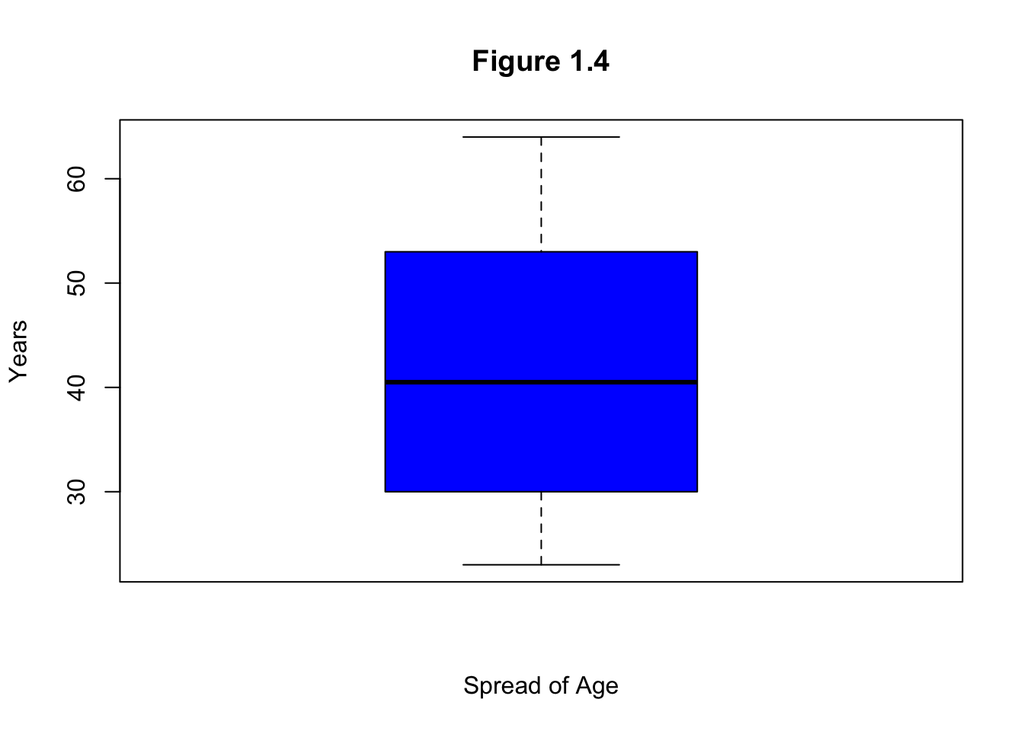

#### Spread of BMI

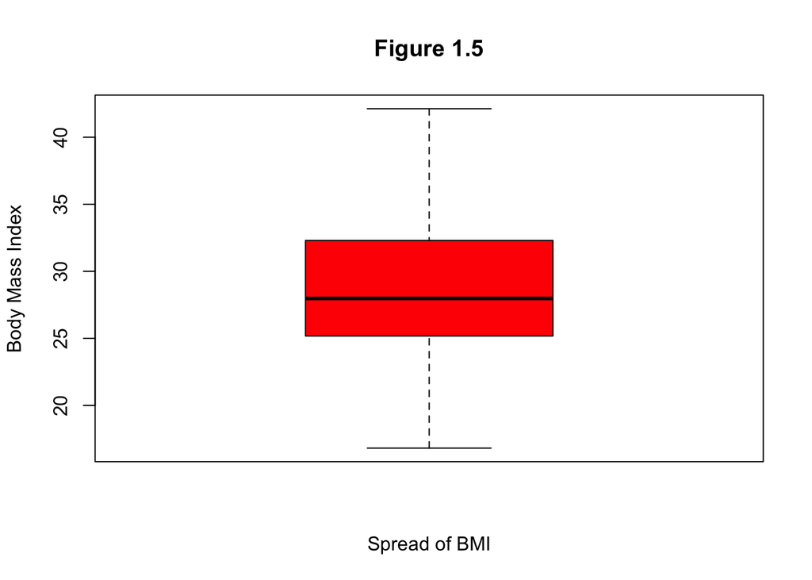

#### Spread of Children

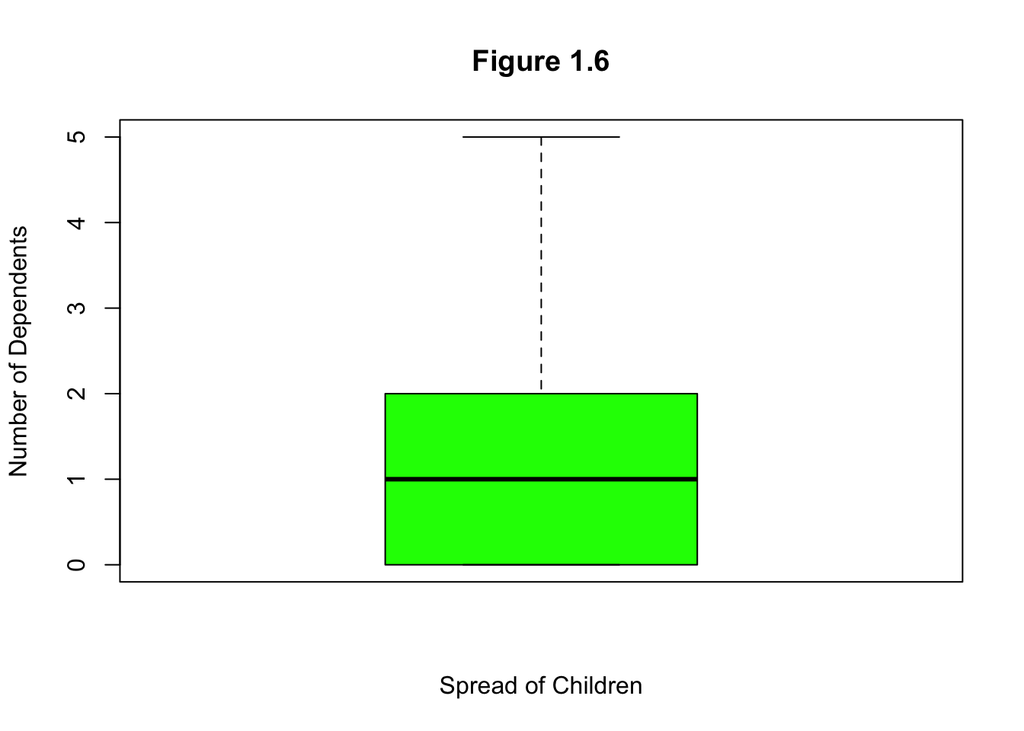

## Question 2

Perform bivariate analyses on the quantitative variables (direction, strength and form). Describe the linear association between all variables.

Quantitative Variable Correlations:

### Relationship

Age - Charges | The strongest positive correlation is between the age of customers and their charges. As per their correlation relationship, which is 0.411474, states that this is a positive and moderate correlation. The grouping within the scatterplot confirms this.

```
## [1] 0.411474
```

BMI - Charges | The correlation between BMI and Charges is positive but weak at 0.1395063. The grouping is sporadic but does follow a slight grouping pattern.

```
## [1] 0.1395063
```

```
## [1] 0.0149766
```

### Strength

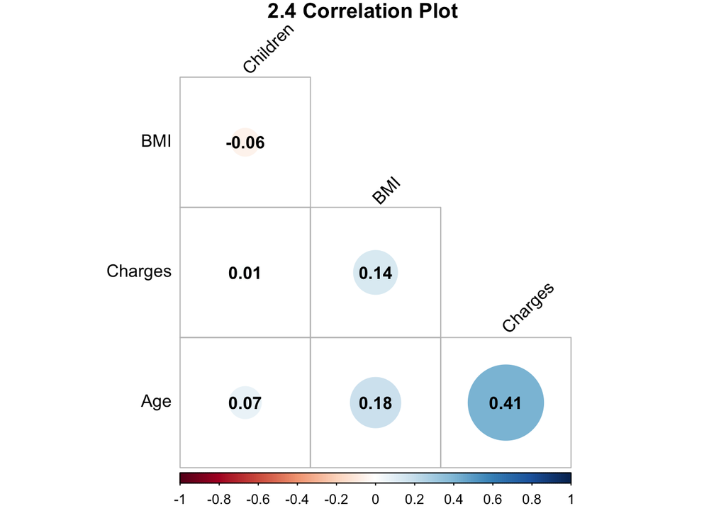

### Form

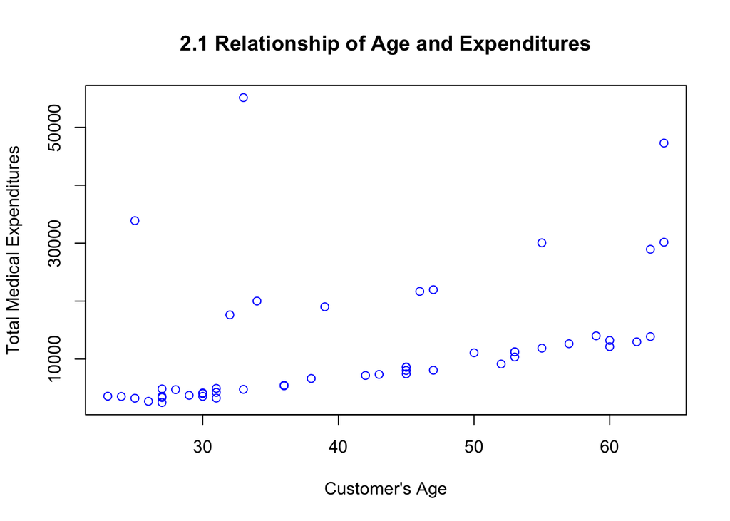

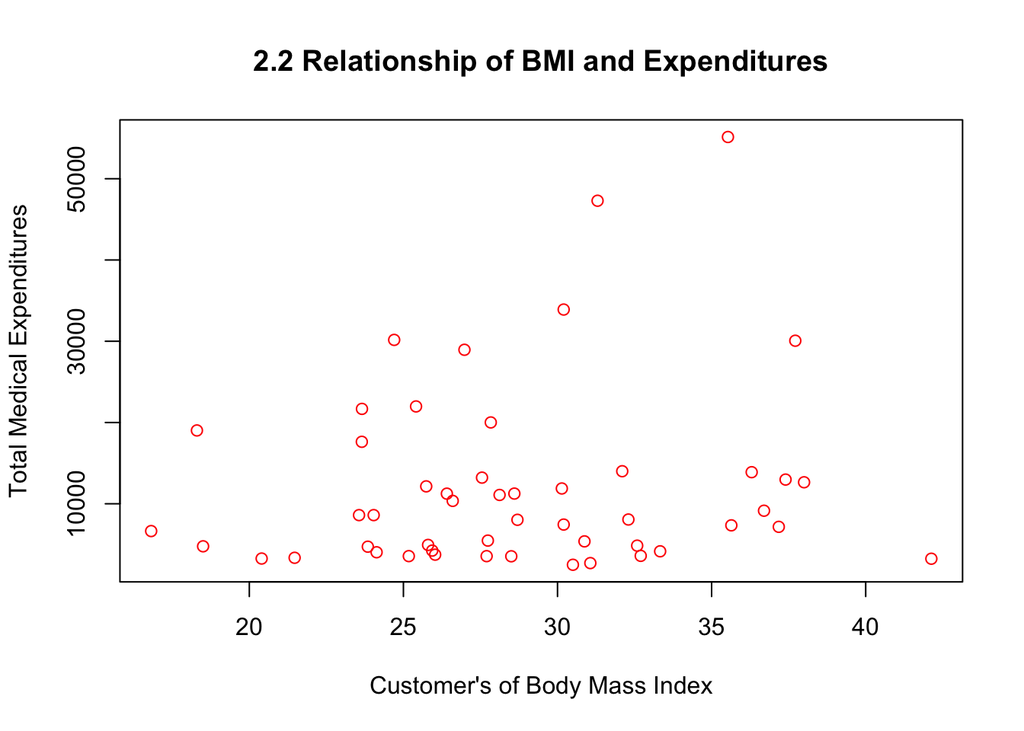

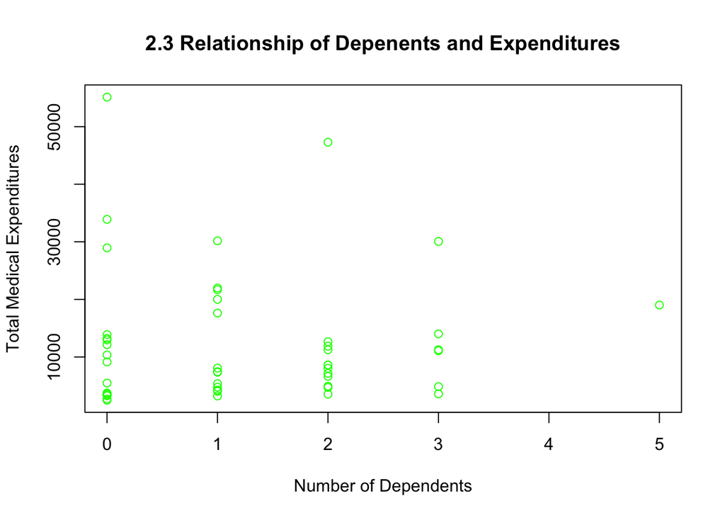

## Question 3

Generate a regression equation in the following form:

[output not shown]

### Regression Equation for Annual Medical Expenses

```
## MODEL INFO:
## Observations: 50
## Dependent Variable: Charges
## Type: OLS linear regression
##
## MODEL FIT:
## F(3,46) = 3.22, p = 0.03
## R² = 0.17
## Adj. R² = 0.12
##
## Standard errors: OLS
## ------------------------------------------------------
##                         Est.      S.E.   t val.      p
## ----------------- ---------- --------- -------- ------
## (Intercept)         -5961.96   8845.53    -0.67   0.50
## Age                   346.51    118.46     2.93   0.01
## BMI                   133.04    277.48     0.48   0.63
## Children             -107.31   1308.07    -0.08   0.93
## ------------------------------------------------------
```

$$Charges = -5962.00 + 346.50(Age) +
133.00(BMI) - 107.30(Children)$$

## Question 4

An eager insurance representative comes back with a potential client. The client is 40, their BMI is 30, and they have one dependent. Using the regression equation above, predict the amount of medical expenses associated with this policy. (Provide a 95% confidence interval as well)

### New Prediction for Medical Expenses

```
##        fit      lwr      upr
## 1 11782.35 8598.572 14966.13
```

As per our regression equation, this Florida health insurance company can expect charges for this individual to annually be $11,782.35. However with a 95% confidence interval the lower bound of charges accumulated would be $8,598.57 to $14,966.13 annually.